# Pump it Up: Data Mining the Water Table

## Hosted by DrivenData

### Code and model development by Kelsey Ayers

First I need to import the data set.

```r
library(readr)
Training.DF <- read_csv("TrainingSetIndependent.csv")
```

#### Explore and pre-process the data

```r
summary(Training.DF)
```

```
##        id          amount_tsh       date_recorded         funder
##  Min.   :    0   Min.   :     0.0   Length:59400       Length:59400
##  1st Qu.:18520   1st Qu.:     0.0   Class :character   Class :character
##  Median :37062   Median :     0.0   Mode  :character   Mode  :character
##  Mean   :37115   Mean   :   317.7
##  3rd Qu.:55657   3rd Qu.:    20.0
##  Max.   :74247   Max.   :350000.0
##    gps_height      installer           longitude        latitude
##  Min.   : -90.0   Length:59400       Min.   : 0.00   Min.   :-11.649
##  1st Qu.:   0.0   Class :character   1st Qu.:33.09   1st Qu.: -8.541
##  Median : 369.0   Mode  :character   Median :34.91   Median : -5.022
##  Mean   : 668.3                      Mean   :34.08   Mean   : -5.706
##  3rd Qu.:1319.2                      3rd Qu.:37.18   3rd Qu.: -3.326
##  Max.   :2770.0                      Max.   :40.35   Max.   :  0.000
##    wpt_name          num_private           basin
##  Length:59400       Min.   :   0.0000   Length:59400
##  Class :character   1st Qu.:   0.0000   Class :character
##  Mode  :character   Median :   0.0000   Mode  :character
##                     Mean   :   0.4741
##                     3rd Qu.:   0.0000
##                     Max.   :1776.0000
##   subvillage           region           region_code   district_code
##  Length:59400       Length:59400       Min.   : 1.0   Min.   : 0.00
##  Class :character   Class :character   1st Qu.: 5.0   1st Qu.: 2.00
##  Mode  :character   Mode  :character   Median :12.0   Median : 3.00
##                                        Mean   :15.3   Mean   : 5.63
##                                        3rd Qu.:17.0   3rd Qu.: 5.00
##                                        Max.   :99.0   Max.   :80.00
##      lga                ward             population      public_meeting
##  Length:59400       Length:59400       Min.   :    0.0   Mode :logical
##  Class :character   Class :character   1st Qu.:    0.0   FALSE:5055
##  Mode  :character   Mode  :character   Median :   25.0   TRUE :51011
##                                        Mean   :  179.9   NA's :3334
##                                        3rd Qu.:  215.0
##                                        Max.   :30500.0
##  recorded_by        scheme_management  scheme_name          permit
##  Length:59400       Length:59400       Length:59400       Mode :logical
##  Class :character   Class :character   Class :character   FALSE:17492
##  Mode  :character   Mode  :character   Mode  :character   TRUE :38852
##                                                           NA's :3056
```

[output cut: 29 more lines]

```
##
##     source          source_type        source_class
##  Length:59400       Length:59400       Length:59400
##  Class :character   Class :character   Class :character
##  Mode  :character   Mode  :character   Mode  :character
##
##
##
##  waterpoint_type    waterpoint_type_group
##  Length:59400       Length:59400
##  Class :character   Class :character
##  Mode  :character   Mode  :character
##
##
##
```

I need to pre-process some of this data. The variables are not properly coded to the correct data types. I reclassified variables to the appropriate data types, mostly converting to factors.

```r
library(dplyr)
Training.DF$id <- as.character(Training.DF$id)
Training.DF$funder <- as.factor(Training.DF$funder)
Training.DF$installer <- as.factor(Training.DF$installer)
Training.DF$district_code <- as.factor(Training.DF$district_code)
Training.DF$region_code <- as.factor(Training.DF$region_code)
Training.DF$region <- as.factor(Training.DF$region)
Training.DF$basin <- as.factor(Training.DF$basin)
Training.DF$subvillage <- as.factor(Training.DF$subvillage)
Training.DF$construction_year <- as.factor(Training.DF$construction_year)
Training.DF$recorded_by <- as.factor(Training.DF$recorded_by)
Training.DF$lga <- as.factor(Training.DF$lga)
Training.DF$ward <- as.factor(Training.DF$ward)
Training.DF$public_meeting <- as.factor(Training.DF$public_meeting)
Training.DF$scheme_management <- as.factor(Training.DF$scheme_management)
Training.DF$scheme_name <- as.factor(Training.DF$scheme_name)
Training.DF$permit <- as.factor(Training.DF$permit)
Training.DF$extraction_type <- as.factor(Training.DF$extraction_type)
Training.DF$extraction_type_group <- as.factor(Training.DF$extraction_type_group)
Training.DF$extraction_type_class <- as.factor(Training.DF$extraction_type_class)
Training.DF$management <- as.factor(Training.DF$management)
Training.DF$management_group <- as.factor(Training.DF$management_group)
Training.DF$payment_type <- as.factor(Training.DF$payment_type)
Training.DF$water_quality <- as.factor(Training.DF$water_quality)
Training.DF$quality_group <- as.factor(Training.DF$quality_group)
Training.DF$quantity <- as.factor(Training.DF$quantity)
Training.DF$quantity_group <- as.factor(Training.DF$quantity_group)
Training.DF$source <- as.factor(Training.DF$source)
Training.DF$source_type <- as.factor(Training.DF$source_type)
Training.DF$source_class <- as.factor(Training.DF$source_class)
Training.DF$waterpoint_type <- as.factor(Training.DF$waterpoint_type)
Training.DF$waterpoint_type_group <- as.factor(Training.DF$waterpoint_type_group)
```

Next I need to blend the independent variables with my dependent variable - status group.

```r
TrainingResults.DF <- read_csv("TrainingSetDependent.csv")
summary(TrainingResults.DF)
```

These variables are also miscoded.

```r
TrainingResults.DF$id <- as.character(TrainingResults.DF$id)
TrainingResults.DF$status_group <- factor(TrainingResults.DF$status_group,levels=c("functional","functional needs repair","non functional"),labels=c("1","2","3"))
```

Blend the data sets.

```r
Working.DF <- merge(x=Training.DF,y=TrainingResults.DF,by="id")
```

Several of the variables in this data set are redundant. For instance, region & region code contain the same data just in different ways. I removed these redundancies, only leaving the variables I need for analysis.

```r
Working2.DF <- Working.DF[,c(-1,-4,-6,-9,-10,-11,-12,-13,-16,-17,-20,-21,-22,-24,-25,-26,-28,
                            -30,-32,-34,-36,-37,-39)]
```

Get a high level view of my data set using ggplot. See if there is any obvious correlation.

```r
library(ggplot2)
```

Is there one region with more failing wells than the others? We can see that Region 24 has virtually no failing wells, and that region 40 has no operational wells.

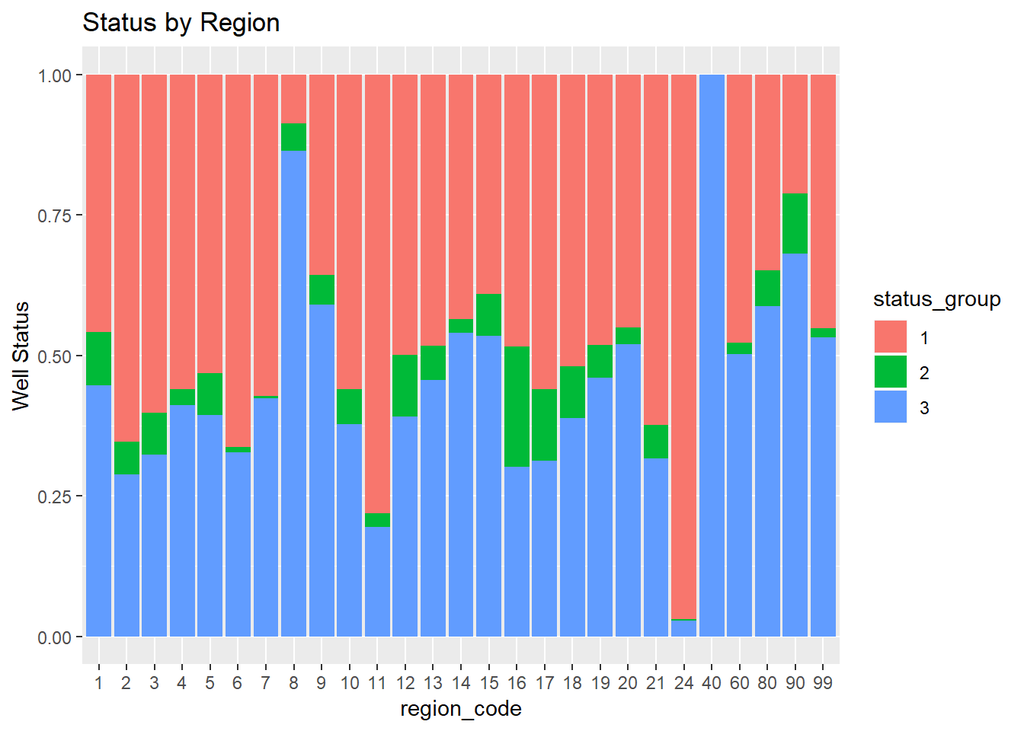

```r
ggplot(Working2.DF,aes(x=region_code,fill=status_group)) + geom_bar(position="fill") +
  labs(y="Well Status")+labs(title="Status by Region")
```

Does the payment type have any correlation? It seems that those that never pay represent a high percentage of the wells that have failed, while those that pay per bucket represent a good portion of those that are functional.

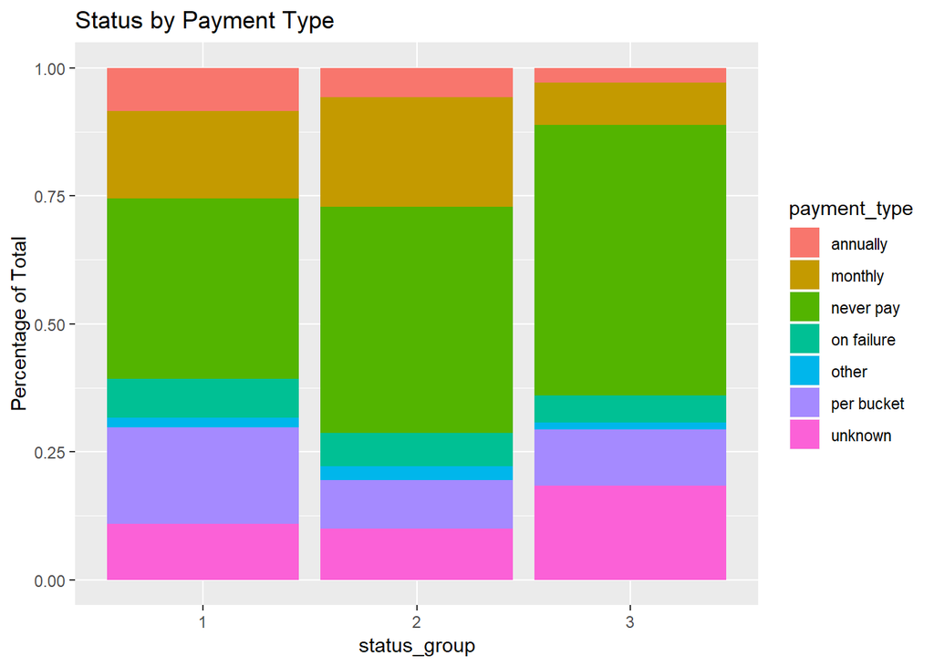

```r
ggplot(Working2.DF,aes(x=status_group,fill=payment_type)) + geom_bar(position="fill") +
  labs(y="Percentage of Total")+labs(title="Status by Payment Type")
```

#### Build the model

With so many observations and “noisy” data, it could be too computationally expensive to run a decision tree or random forest model. While k-Nearest Neighbors can also be computationally expensive it is less so. While it would be ideal to understand what contributes to well failure, it’s most important to identify them proactively. So, while kNN isn’t a perfect solution, it gets us halfway there. In order to do this, though, we need to dummy the variables.

```r
library(dummies)
TrainingKNN.DF <- Working2.DF
dum.public_meeting <- dummy("public_meeting",TrainingKNN.DF)
dum.permit <- dummy("permit",TrainingKNN.DF)
dum.extraction_type_class <- dummy("extraction_type_class",TrainingKNN.DF)
dum.management_group <- dummy("management_group",TrainingKNN.DF)
dum.payment_type <- dummy("payment_type",TrainingKNN.DF)
dum.quality_group <- dummy("quality_group",TrainingKNN.DF)
dum.quantity_group <- dummy("quantity_group",TrainingKNN.DF)
dum.source_class <- dummy("source_class",TrainingKNN.DF)
dum.waterpoint_type_group <- dummy("waterpoint_type_group",TrainingKNN.DF)

dummies <- as.data.frame(cbind(
                 dum.public_meeting[,c(1:ncol(dum.public_meeting)-1)],
                 dum.permit[,c(1:ncol(dum.permit)-1)],
                 dum.extraction_type_class[,c(1:ncol(dum.extraction_type_class)-1)],
                 dum.management_group[,c(1:ncol(dum.management_group)-1)],
                 dum.payment_type[,c(1:ncol(dum.payment_type)-1)],
                 dum.quality_group[,c(1:ncol(dum.quality_group)-1)],
                 dum.quantity_group[,c(1:ncol(dum.quantity_group)-1)],
                 dum.source_class[,c(1:ncol(dum.source_class)-1)],
                 dum.waterpoint_type_group[,c(1:ncol(dum.waterpoint_type_group)-1)]))

continuous <- Working2.DF[,c(1,3,4,5,8)]
KNN.DF <- cbind(continuous,dummies)
scaled.df <- scale(KNN.DF)

KNN.DF <- as.data.frame(cbind(Working2.DF[,18],scaled.df))
colnames(KNN.DF)[1] <- "status_group"
KNN.DF <- KNN.DF[complete.cases(KNN.DF),]
KNN.DF$status_group <- as.factor(KNN.DF$status_group)
```

Partition the data set into a training and a validation set.

```r
library(caret)
trainIndex <- createDataPartition(KNN.DF$status_group,
                                  p=.7,
                                  list=FALSE,
                                  times=1)

knn.train <- KNN.DF[trainIndex,]
knn.valid <- KNN.DF[-trainIndex,]
```

Separate into predictor and target variables to use in k-Nearest Neighbors.

```r
library(class)
library(gplots)
knn.predict <- KNN.DF[,-1]
train.knn.target <- knn.train[,1]
train.knn.predictors <- knn.train[,-1]
valid.knn.predictors <- knn.valid[,-1]
valid.knn.target <- knn.valid[,1]
```

There are 3 categories in status group and the cube root of 59,400 observations is 39. This is divisible by 3, which makes it a poor selection for k. Leaving the model at k = 39 would lead to potentially random selections. Instead, I chose k = 38.

```r
knn38.model <- knn(train=train.knn.predictors,test=valid.knn.predictors,cl=train.knn.target,k=38,prob=TRUE)
prob <- attr(knn38.model,"prob")
preds <- knn(train=train.knn.predictors, test = valid.knn.predictors,
             cl=train.knn.target, k=38, prob=TRUE)
```

#### Results

```r
confusionMatrix(preds, valid.knn.target)
```

```
## Confusion Matrix and Statistics
##
##           Reference
## Prediction    1    2    3
##          1 8645  932 2503
##          2   78  154   49
##          3  954  209 4295
##
## Overall Statistics
##
##                Accuracy : 0.7348
##                  95% CI : (0.7283, 0.7413)
##     No Information Rate : 0.5431
##     P-Value [Acc > NIR] : < 2.2e-16
##
##                   Kappa : 0.4831
##  Mcnemar's Test P-Value : < 2.2e-16
##
## Statistics by Class:
##
##                      Class: 1 Class: 2 Class: 3
## Sensitivity            0.8934 0.118919   0.6273
## Specificity            0.5781 0.992314   0.8940
## Pos Pred Value         0.7156 0.548043   0.7869
## Neg Pred Value         0.8202 0.934941   0.7935
## Prevalence             0.5431 0.072675   0.3843
## Detection Rate         0.4852 0.008642   0.2410
## Detection Prevalence   0.6779 0.015770   0.3063
## Balanced Accuracy      0.7357 0.555617   0.7606
```